# Activity-1-NBA-Goat

## Activity 1 - NBA

#### You are a data scientist. You work for the NBA and you have the impossible task of answering who is the GOAT of the NBA between Michael Jordan and Lebron James. Use data science to answer this question.

IMPORTANT: There are parts in the code marked as "# TASK: ", you will have to add code after those parts.

Task 1. Load each player data to a Pandas Dataframe (provided)

```python
#!pip install pandas
import pandas

# Here is a Dictionary with the NBA historical results of Lebron James from 2003 to 2022
lebron_data = {
    'Season': ['2003-04', '2004-05', '2005-06', '2006-07', '2007-08', '2008-09', '2009-10', '2010-11', '2011-12', '2012-13', '2013-14', '2014-15', '2015-16', '2016-17', '2017-18', '2018-19', '2019-20', '2020-21', '2021-22'],
    'Team': ['CLE', 'CLE', 'CLE', 'CLE', 'CLE', 'CLE', 'CLE', 'MIA', 'MIA', 'MIA', 'MIA', 'CLE', 'CLE', 'CLE', 'CLE', 'LAL', 'LAL', 'LAL', 'LAL'],
    'Games_Played': [79, 80, 79, 78, 75, 81, 76, 79, 62, 76, 77, 69, 76, 74, 82, 55, 67, 45, 56],
    'Points_Per_Game': [20.9, 27.2, 31.4, 27.3, 30.0, 28.4, 29.7, 26.7, 27.1, 26.8, 27.1, 25.3, 25.3, 26.4, 27.5, 27.4, 25.3, 25.0, 30.3]
}

# TASK: Create a Pandas DataFrame using the lebron_data dictionary
# Remmember to import the Pandas library
# -YOUR CODE HERE-

df_lebron = pandas.DataFrame.from_dict(lebron_data, orient='index')
df_lebron.head()
```

|  | 0 | 1 | 2 | 3 | 4 | 5 | 6 | 7 | 8 | 9 | 10 | 11 | 12 | 13 | 14 | 15 | 16 | 17 | 18 |
| --- | --- | --- | --- | --- | --- | --- | --- | --- | --- | --- | --- | --- | --- | --- | --- | --- | --- | --- | --- |
| Season | 2003-04 | 2004-05 | 2005-06 | 2006-07 | 2007-08 | 2008-09 | 2009-10 | 2010-11 | 2011-12 | 2012-13 | 2013-14 | 2014-15 | 2015-16 | 2016-17 | 2017-18 | 2018-19 | 2019-20 | 2020-21 | 2021-22 |
| Team | CLE | CLE | CLE | CLE | CLE | CLE | CLE | MIA | MIA | MIA | MIA | CLE | CLE | CLE | CLE | LAL | LAL | LAL | LAL |
| Games_Played | 79 | 80 | 79 | 78 | 75 | 81 | 76 | 79 | 62 | 76 | 77 | 69 | 76 | 74 | 82 | 55 | 67 | 45 | 56 |
| Points_Per_Game | 20.9 | 27.2 | 31.4 | 27.3 | 30.0 | 28.4 | 29.7 | 26.7 | 27.1 | 26.8 | 27.1 | 25.3 | 25.3 | 26.4 | 27.5 | 27.4 | 25.3 | 25.0 | 30.3 |

```python
jordan_data = {
    'Season': ['1984-85', '1985-86', '1986-87', '1987-88', '1988-89', '1989-90', '1990-91', '1991-92', '1992-93', '1994-95', '1995-96', '1996-97', '1997-98', '1998-99', '1999-00', '2000-01', '2001-02', '2002-03'],
    'Team': ['CHI', 'CHI', 'CHI', 'CHI', 'CHI', 'CHI', 'CHI', 'CHI', 'CHI', 'CHI', 'CHI', 'CHI', 'CHI', 'NA', 'NA', 'NA', 'WAS', 'WAS'],
    'Games_Played': [82, 18, 82, 82, 81, 82, 82, 80, 78, 17, 82, 82, 82, 0, 0, 0, 60, 82],
    'Points_Per_Game': [28.2, 22.7, 37.1, 35.0, 32.5, 33.6, 31.5, 30.1, 32.6, 26.9, 30.4, 29.6, 28.7, 0, 0, 0,22.9, 20.0]
}

# TASK: Create a Pandas DataFrame using the lebron_data dictionary
# Remmember to import the Pandas library
# -YOUR CODE HERE-
df_jordan = pandas.DataFrame.from_dict(jordan_data, orient='index')
df_jordan.head()
```

|  | 0 | 1 | 2 | 3 | 4 | 5 | 6 | 7 | 8 | 9 | 10 | 11 | 12 | 13 | 14 | 15 | 16 | 17 |
| --- | --- | --- | --- | --- | --- | --- | --- | --- | --- | --- | --- | --- | --- | --- | --- | --- | --- | --- |
| Season | 1984-85 | 1985-86 | 1986-87 | 1987-88 | 1988-89 | 1989-90 | 1990-91 | 1991-92 | 1992-93 | 1994-95 | 1995-96 | 1996-97 | 1997-98 | 1998-99 | 1999-00 | 2000-01 | 2001-02 | 2002-03 |
| Team | CHI | CHI | CHI | CHI | CHI | CHI | CHI | CHI | CHI | CHI | CHI | CHI | CHI | NA | NA | NA | WAS | WAS |
| Games_Played | 82 | 18 | 82 | 82 | 81 | 82 | 82 | 80 | 78 | 17 | 82 | 82 | 82 | 0 | 0 | 0 | 60 | 82 |
| Points_Per_Game | 28.2 | 22.7 | 37.1 | 35.0 | 32.5 | 33.6 | 31.5 | 30.1 | 32.6 | 26.9 | 30.4 | 29.6 | 28.7 | 0 | 0 | 0 | 22.9 | 20.0 |

Task 2. First let's see the points per game (ppg) for each player did in their first 15 seasons.

1. Create a Numpy Array with Lebron's first 15 season's points per game named: lebron_ppg. (IMPORTANT: Lebron has 19 seasons so far, you need to take only first 15 seasons)
2. Create a Numpy Array with Jordan's first 15 season's points per game named: jordan_ppg. (IMPORTANT: Jordan did not played for 3 seasons, you need ignore those seasons)
3. Use Matplotlib to graph the points per game per season of both players in a single graph:

   b) Add required library for Matplotlib --> import matplotlib.pyplot as plt

   c) Generate a figure of size 10, 6 --> plt.figure(figsize=(10,6))

   d) Add first plot (plt.plot), and add as parameters: seasons array, lebron ppg array, add label and a marker.

   e) Add a second plot with Jordans points per game

   f) Add labels for x axis, y axis and title

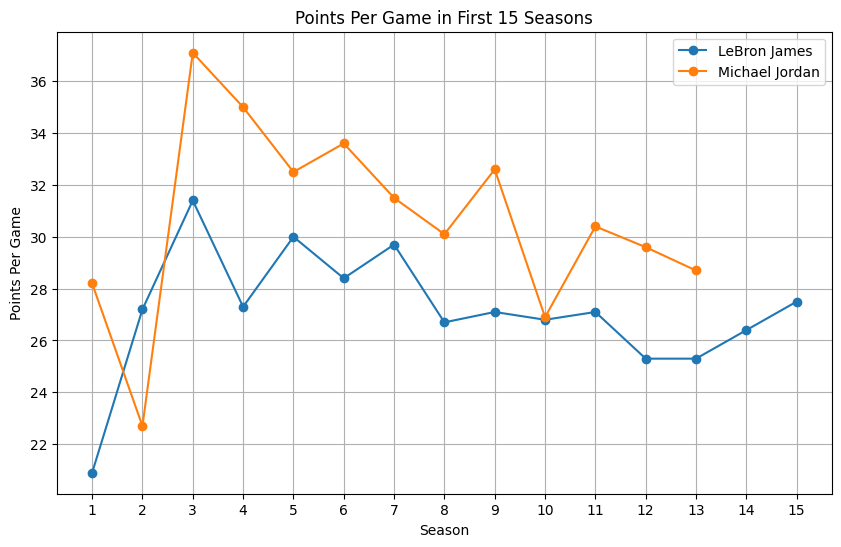

```python
# TASK: Add the required libraries (Numpy and Matplotlib) to create a graph with the points per game of both players
import numpy as np
import matplotlib.pyplot as plt

# TASK: Create a Numpy Array with Lebron's first 15 season's points per game name that array lebron_ppg
lebron_ppg = df_lebron.loc['Points_Per_Game'].astype(float)[:15].to_numpy()

# TASK: Create a Numpy Array with Jordan's first 15 season's points per game (then we will remove seasons he didn't play)
jordan_ppg = df_jordan.loc['Points_Per_Game'].astype(float)[:15].to_numpy()

# IMPORTANT: Michael Jordan did not play from the 1998 season to the 2000 season, so you need to skip those seasons in the array
# IMPORTANT: Michael Jordan did not play from the 1998 season to the 2000 season, so you need to skip those seasons in the array
# You can identify those seasons in jordan dataframe with the 'NA' value in the 'Team' column
# Find indices where Team is 'NA' in the first 15 seasons
na_indices = [i for i, team in enumerate(df_jordan.loc['Team'][:15]) if team == 'NA']
jordan_ppg = np.delete(jordan_ppg, na_indices)
# TASK: Create a Numpy Array with numbers from 1 to 15 to represent the seasons name that array 'seasons'
seasons = np.arange(1, 16)
# Create a seasons array for Jordan by removing the seasons he didn't play – this will have length 13
seasons_jordan = np.delete(seasons, na_indices)

# TASK: Use Matplotlib to graph the points per game per season of both players in a single graph
# Title of the graph should be 'Points Per Game in First 15 Seasons'
# X Label should be the 'Season'
# Y Label should be 'Points Per Game'

plt.figure(figsize=(10,6))
# Plot LeBron across all 15 seasons
plt.plot(seasons, lebron_ppg, marker='o', label='LeBron James')
# Plot Jordan only on the seasons he actually played (13 values) using seasons_jordan
plt.plot(seasons_jordan, jordan_ppg, marker='o', label='Michael Jordan')
plt.title('Points Per Game in First 15 Seasons')
plt.xlabel('Season')
plt.ylabel('Points Per Game')
plt.xticks(seasons)
plt.legend()
plt.grid()
plt.show()
```

Task 3. If we only look at ppg we might have a clear winner, let's add information about assists:

```
i) Bellow you will see how we are adding the assists per game (apg) to the original Dictionary

ii) Create a pandas dataframe with the updated python dictionary

iii) Show the pandas dataframe of each player, you should see these columns: 'Season', 'Team', 'Games_Played', 'Points_Per_Game', 'Assists_Per_Game'. (you can use print)
```

```python
# Here we are adding a new field to our Python Dictionary:

# lebron_data dictionary will now have a new key called 'Assists_Per_Game' with the following values
lebron_data['Assists_Per_Game'] = [5.9, 7.2, 6.6, 6.0, 7.2, 7.2, 8.6, 7.0, 6.2, 7.3, 6.3, 7.4, 6.8, 8.7, 9.1, 8.3, 10.2, 7.8, 6.2]

# jordan_data dictionary will now have a new key called 'Assists_Per_Game' with the following values
jordan_data['Assists_Per_Game'] = [5.9, 2.9, 4.6, 5.9, 8.0, 6.3, 5.5, 6.1, 5.5, 5.3, 4.3, 4.3, 3.5, 0, 0, 0, 5.2, 3.8]

# TASK: Create a Pandas DataFrame using the updated lebron_data and jordan_data dictionaries
# Call them lebron_df and jordan_df respectively

lebron_df = pandas.DataFrame.from_dict(lebron_data)
jordan_df = pandas.DataFrame.from_dict(jordan_data)

# TASK: Print both DataFrames to see the updated data
print(lebron_df)
print(jordan_df)
```

```
     Season Team  Games_Played  Points_Per_Game  Assists_Per_Game
0   2003-04  CLE            79             20.9               5.9
1   2004-05  CLE            80             27.2               7.2
2   2005-06  CLE            79             31.4               6.6
3   2006-07  CLE            78             27.3               6.0
4   2007-08  CLE            75             30.0               7.2
5   2008-09  CLE            81             28.4               7.2
6   2009-10  CLE            76             29.7               8.6
7   2010-11  MIA            79             26.7               7.0
8   2011-12  MIA            62             27.1               6.2
9   2012-13  MIA            76             26.8               7.3
10  2013-14  MIA            77             27.1               6.3
11  2014-15  CLE            69             25.3               7.4
12  2015-16  CLE            76             25.3               6.8
13  2016-17  CLE            74             26.4               8.7
```

[output cut: 24 more lines]

Task 4. Similar to the points per game, create a graph that now shows the Assists Per Game.

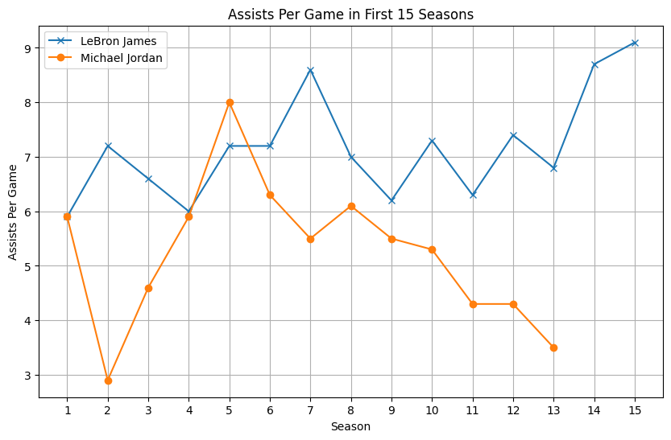

```python
# TASK: Create a Numpy Array with Lebron's first 15 season's assists per game

lebron_apg = lebron_df['Assists_Per_Game'][:15].to_numpy()

# TASK: Create a Numpy Array with Jordan's first 15 season's assists per game
jordan_apg = jordan_df['Assists_Per_Game'][:15].to_numpy()

# TASK: Use Matplotlib to graph the assists per game per season of both players in a single graph
# Call the x-axis 'Season' and the y-axis 'Assists Per Game'
# Graph title should be 'Assists Per Game in First 15 Seasons'
# Plot label for Michael Jordan should be 'Michael Jordan' and for LeBron James should be 'LeBron James'
# Plot marker for Michael Jordan should be 'o' and for LeBron James should be 'x'

plt.figure(figsize=(10,6))
# Plot LeBron across all 15 seasons
plt.plot(seasons, lebron_apg, marker='x', label='LeBron James')
# Plot Jordan only on the seasons he actually played (13 values) using seasons_jordan
plt.plot(seasons_jordan, np.delete(jordan_apg, na_indices), marker='o', label='Michael Jordan')
plt.title('Assists Per Game in First 15 Seasons')
plt.xlabel('Season')
plt.ylabel('Assists Per Game')
plt.xticks(seasons)
plt.legend()
plt.grid()
plt.show()
```

Task 5. Now it is getting complicated to know who is the best. Michael Jordan has better ppg (points per game) but Lebron more apg (assists per game).

We could use a know formula that calculated how effective a player is, called the Player Efficiency Rating Formula:

```
PER = ppg + rpg + apg + spg + bpg - mfg - mft - tpg
Where:
    ppg = point per game
    rpg = rebounds per game
    apg = assists per game
    bpg = blocks per game
    mfg = missed field goals per game
    mft = missed free throws per game
    tpg = turnovers per game
```

You will be provided with these values, you will have to:

1. Use these metrics to calculate the PER
2. Create another column in your dataframe called PER (player efficiency rating) with the calculated value based on the formula
3. Generate a graph that has both players PER
4. Generate you conclusions on who is the best player:

```python
# Data for all required statistics
# IMPORTANT: These are Python Lists, consider create a Numpy Array for each one for the PER calculation
# Remmember you already have the points per game and assists per game for both players as Numpy Arrays
# These next lists have already filtered the seasons that Michael Jordan did not play


# Rebounds Per Game Per Season for both players (Python List)
lebron_rpg = [5.5, 7.4, 7.0, 6.7, 7.9, 7.6, 7.3, 7.5, 7.9, 8.0, 6.9, 6.0, 7.4, 8.6, 8.6, 8.5, 7.8, 7.7, 8.0]
jordan_rpg = [6.5, 3.6, 5.2, 5.5, 8.0, 6.9, 6.0, 6.4, 6.7, 6.9, 6.6, 5.9, 5.8, 0, 0, 0, 5.7, 6.1]

# Steals Per Game Per Season for both players (Python List)
lebron_spg = [1.6, 2.2, 1.6, 1.6, 1.8, 1.7, 1.6, 1.6, 1.9, 1.7, 1.6, 1.6, 1.4, 1.2, 1.4, 1.3, 1.2, 1.1, 1.3]
jordan_spg = [2.4, 2.1, 2.9, 3.2, 2.9, 2.8, 2.7, 2.3, 2.8, 1.8, 2.2, 1.7, 1.7, 0, 0, 0, 1.4, 1.5]

# Blocks Per Game Per Season for both players (Python List)
lebron_bpg = [0.7, 0.7, 0.8, 0.7, 1.1, 1.1, 1.0, 0.6, 0.8, 0.9, 0.3, 0.7, 0.6, 0.6, 0.9, 0.6, 0.5, 0.6, 1.1]
jordan_bpg = [0.8, 1.2, 1.5, 1.6, 0.8, 0.7, 1.0, 0.9, 0.8, 0.8, 0.8, 0.5, 0.5, 0.0, 0.0, 0.0, 0.4, 0.5]

# Turnovers Per Game Per Season for both players (Python List)
lebron_tpg = [3.5, 3.3, 3.3, 3.2, 3.4, 3.0, 3.4, 3.6, 3.4, 3.0, 3.5, 3.9, 3.3, 4.1, 4.2, 3.6, 3.9, 3.7, 3.5]
jordan_tpg = [3.5, 2.5, 3.3, 3.1, 3.6, 3.0, 2.5, 2.5, 2.7, 2.1, 2.4, 2.3, 2.1, 0, 0, 0, 2.7, 2.4]

# Field Goals Missed Per Game (Attempted - Made / Games) Per Season for both players (Python List)
lebron_fgm = [11.0, 11.2, 12.0, 11.8, 11.9, 10.1, 8.8, 8.1, 9.3, 7.7, 7.6, 9.4, 7.4, 9.8, 8.9, 12.0, 9.8, 12.2, 11.7]
jordan_fgm = [9.6, 25.4, 14.4, 11.2, 10.2, 12.0, 10.8, 10.9, 12.9, 27.6, 11.3, 11.9, 12.3, 0, 0, 0, 10.8, 9.2]

# Free Trows Missed Per Game (Attempted - Made / Games) Per Season for both players (Python List)
lebron_ftm = [1.4, 1.6, 2.7, 2.2, 3.0, 2.1, 2.4, 2.0, 1.9, 1.7, 1.9, 1.9, 1.7, 1.8, 1.8, 2.3, 1.9, 2.6, 2.3]
jordan_ftm = [1.4, 2.6, 1.7, 1.9, 1.1, 1.2, 1.6, 1.6, 1.6, 3.5, 1.9, 1.5, 2.1, 0, 0, 0, 0.9, 0.8]


# TASK: Generate a Numpy array with Player Efficiency Rating (PER) for each player
# Formula for PER:
#   PER = ppg + rpg + apg + spg + bpg - mfg - mft - tpg
#
# Call the Numpy array for Lebron: lebron_per
# Call the Numpy array for Jordan: jordan_per
lebron_per = pandas.Series(lebron_data['Points_Per_Game']) + pandas.Series(lebron_rpg) + pandas.Series(lebron_data['Assists_Per_Game']) + pandas.Series(lebron_spg) + pandas.Series(lebron_bpg) - pandas.Series(lebron_fgm) - pandas.Series(lebron_ftm) - pandas.Series(lebron_tpg)
jordan_per = pandas.Series(jordan_data['Points_Per_Game']) + pandas.Series(jordan_rpg) + pandas.Series(jordan_data['Assists_Per_Game']) + pandas.Series(jordan_spg) + pandas.Series(jordan_bpg) - pandas.Series(jordan_fgm) - pandas.Series(jordan_ftm) - pandas.Series(jordan_tpg)

# TASK: Add PER to the dataframes
lebron_df['PER'] = lebron_per
jordan_df['PER'] = jordan_per

# TASK: Print the updated DataFrames
print(lebron_df)
print(jordan_df)
```

```
     Season Team  Games_Played  Points_Per_Game  Assists_Per_Game   PER
0   2003-04  CLE            79             20.9               5.9  18.7
1   2004-05  CLE            80             27.2               7.2  28.6
2   2005-06  CLE            79             31.4               6.6  29.4
3   2006-07  CLE            78             27.3               6.0  25.1
4   2007-08  CLE            75             30.0               7.2  29.7
5   2008-09  CLE            81             28.4               7.2  30.8
6   2009-10  CLE            76             29.7               8.6  33.6
7   2010-11  MIA            79             26.7               7.0  29.7
8   2011-12  MIA            62             27.1               6.2  29.3
9   2012-13  MIA            76             26.8               7.3  32.3
10  2013-14  MIA            77             27.1               6.3  29.2
11  2014-15  CLE            69             25.3               7.4  25.8
12  2015-16  CLE            76             25.3               6.8  29.1
13  2016-17  CLE            74             26.4               8.7  29.8
```

[output cut: 24 more lines]

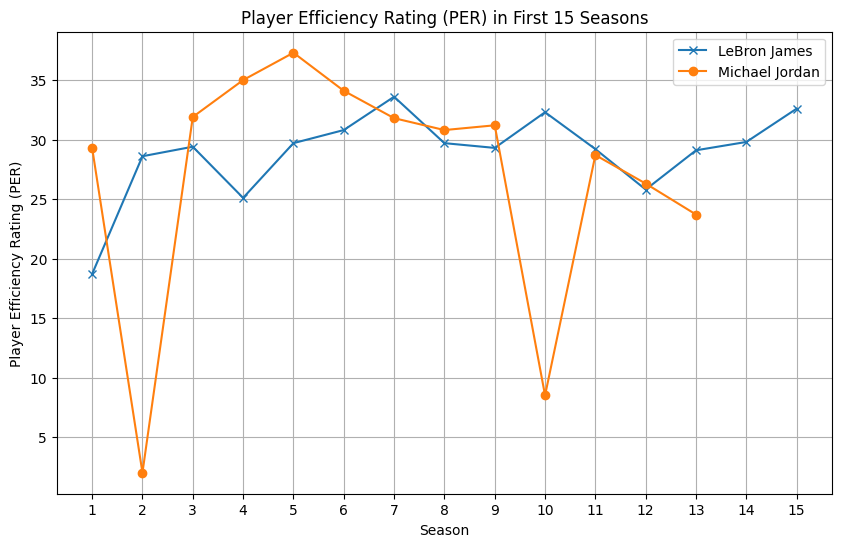

```python
# TASK: Get the Numpy array of Lebron and Jordan PER for the first 15 seasons:
from matplotlib import pyplot as plt


lebron_per = lebron_df['PER'][:15].to_numpy()

# IMPORTANT: Michael Jordan did not play from the 1998 season to the 2000 season, so you need to skip those seasons in the array
jordan_per = jordan_df['PER'][:15].to_numpy()

# Use Matplotlib to graph the Player Efficiency Rating (PER) per season of both players in a single graph
# The graph should have the following:
# - Title: Player Efficiency Rating (PER) in First 15 Seasons
# - X-axis: Season
# - Y-axis: Player Efficiency Rating (PER)
# - Plot the PER of Michael Jordan first 15 seasons and label it as 'Michael Jordan', marker='o'
# - Plot the PER of LeBron James first 15 seasons and label it as 'LeBron James', marker='x'
# - Make sure the graph has grid lines

plt.figure(figsize=(10,6))
# Plot LeBron across all 15 seasons
plt.plot(seasons, lebron_per, marker='x', label='LeBron James')
# Plot Jordan only on the seasons he actually played (13 values) using seasons_jordan
plt.plot(seasons_jordan, np.delete(jordan_per, na_indices), marker='o', label='Michael Jordan')
plt.title('Player Efficiency Rating (PER) in First 15 Seasons')
plt.xlabel('Season')
plt.ylabel('Player Efficiency Rating (PER)')
plt.xticks(seasons)
plt.legend()
plt.grid()
plt.show()
```